# Statistic of token storjcoin

Yen-Ting Chou

10/9/2018

# Project 1

#### Primary Token: 13

#### The 13th largest token: storjcoin

- Load data into dataframe

```r
data <- read.table("./Ethereum token graphs/networkstorjTX.txt", col.names = c("fromNode", "toNode", "unixTime", "tokenAmount"))

price <- read.table("./tokenPrices/storj", skip = 1, col.names = c("Date", "Open", "High", "low", "Close", "Volumn", "MarketCap"))
```

### Data Preprocessing

The total supply of storj: **424,999,998** (Data comes from coinmarketcap)
The Decimal of storj: **8**
The total amount of tokens :
$$424,999,998 * 10^{8}$$
Those transactions which anount is greater than total supply should be remove
The following table shows the result of which user is trying to make a transaction which amount is greater than the total amount of token

```r
supply <- 424999998
decimal <- 8
total_token <- supply*10^decimal
outlier <- subset(data, data$tokenAmount >= total_token)
outlier_cnt <- count(outlier, 'fromNode')
#outlier_cnt
```

### Question 1: Find the distribution of how many times a user buys or sells a token

- Considering those buyer who didn’t sell and those seller who didn’t buy

```r
normal_data <- subset(data, data$tokenAmount < total_token)
sell_and_buy <- intersect(normal_data$fromNode, normal_data$toNode)
all_sell <- count(normal_data, 'fromNode')
all_buy <- count(normal_data, 'toNode')
only_sell <- setdiff(normal_data$fromNode, sell_and_buy)
only_sell <- cbind(only_sell, fill=0)
only_buy <- setdiff(normal_data$toNode, sell_and_buy)
only_buy <- cbind(only_buy, fill=0)
colnames(only_buy)<- c('fromNode', 'freq')
colnames(only_sell)<- c('toNode', 'freq')
sell <- rbind(all_sell, only_buy)
buy <- rbind(all_buy, only_sell)
colnames(sell) <- c('seller', 'transactions')
sell_freq <- count(sell, 'transactions')
colnames(buy) <- c('buyer', 'transactions')
buy_freq <- count(buy, 'transactions')
```

#### Seller

- The plot of seller’s transcractions frequency

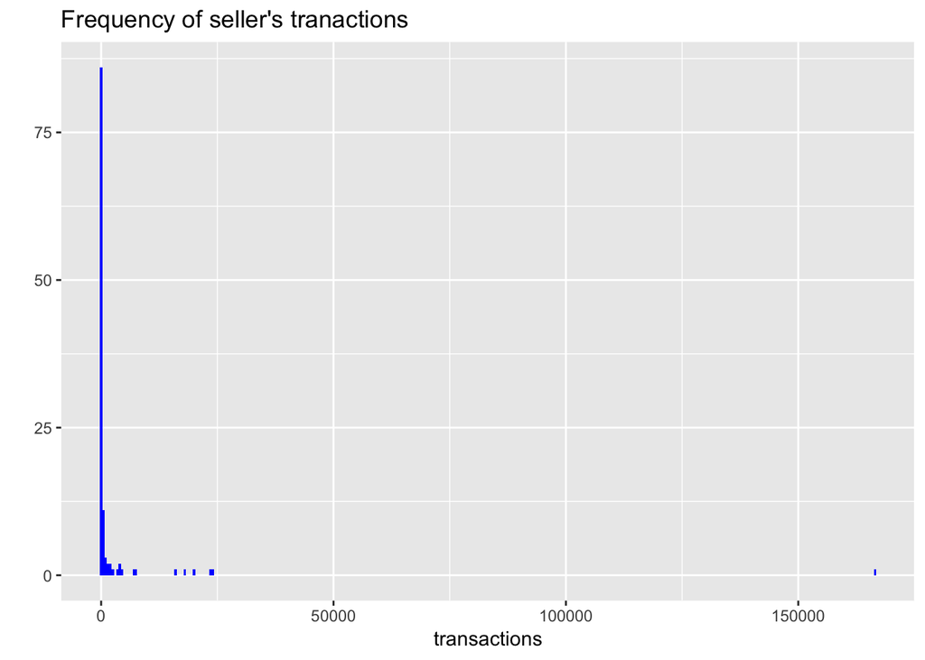

```r
qsell <- qplot(sell_freq$transactions, data = sell_freq,
               geom = "histogram",
               binwidth = 500,
               main = "Frequency of seller's tranactions",
               xlab = "transactions",
               fill=I("blue"))
qsell
```

- Look at the seller transactions frequency stats

```r
#summary(sell_freq)
#head(sell_freq)
#tail(sell_freq)
```

- If we remove frequency 0, and the 166342 transactions data

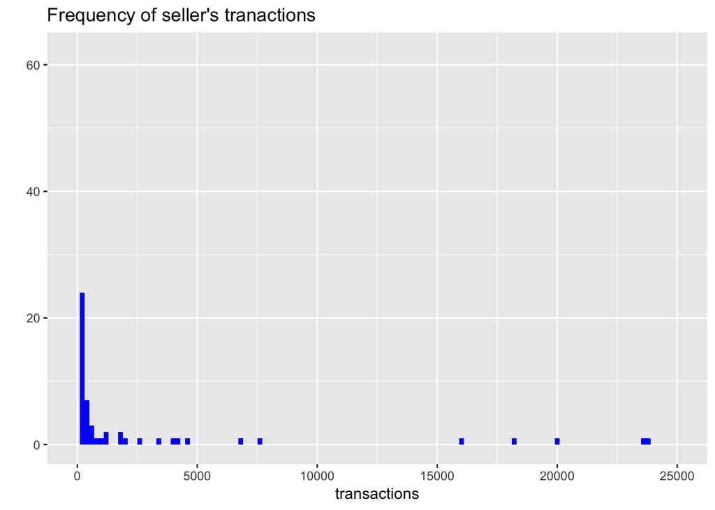

```r
new_sell_freq <- subset(sell_freq, transactions > 0 & transactions < 166342)
#summary(new_sell_freq)
#head(new_sell_freq)
#tail(new_sell_freq)
qplot(new_sell_freq$transactions, data = new_sell_freq,
      geom = "histogram",
      binwidth = 200,
      xlim = c(0, 25000),
      main = "Frequency of seller's tranactions",
      xlab = "transactions",
      fill=I("blue"))
```

#### Trying to fit

- First, use Cullen and Fury graph to see which distribution fit the most
- Lognormal distribution can not fit the data which has zero inside
- Compare the gamma, normal, poison and exponential distribution

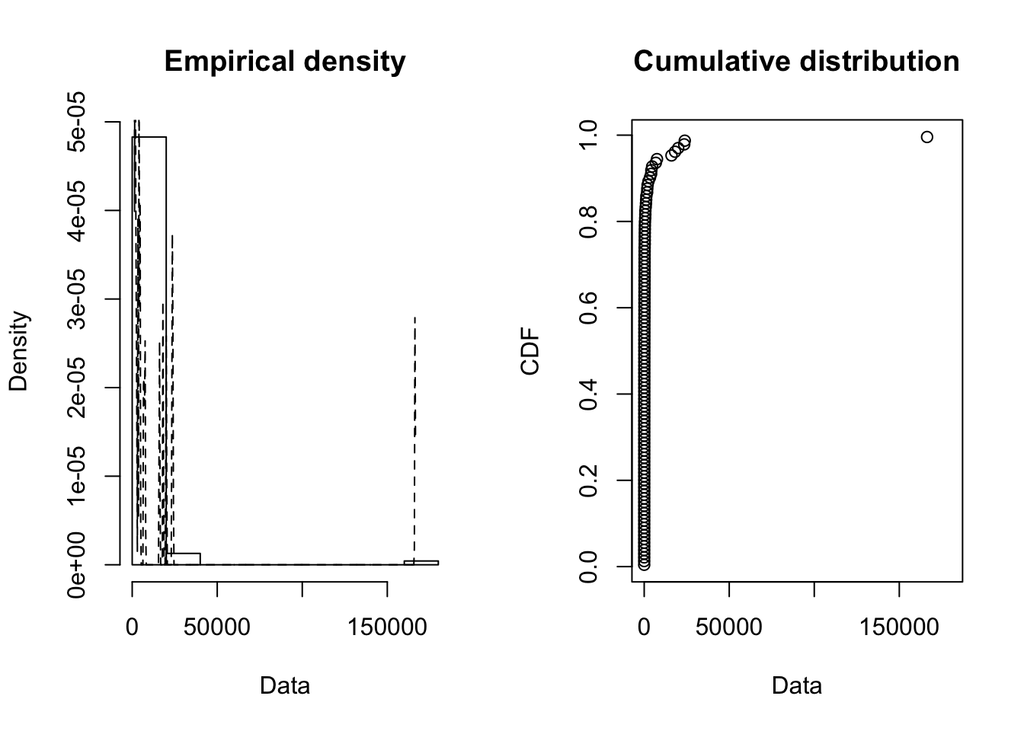

```r
plotdist(sell_freq$transaction, histo = TRUE, demp = TRUE)
```

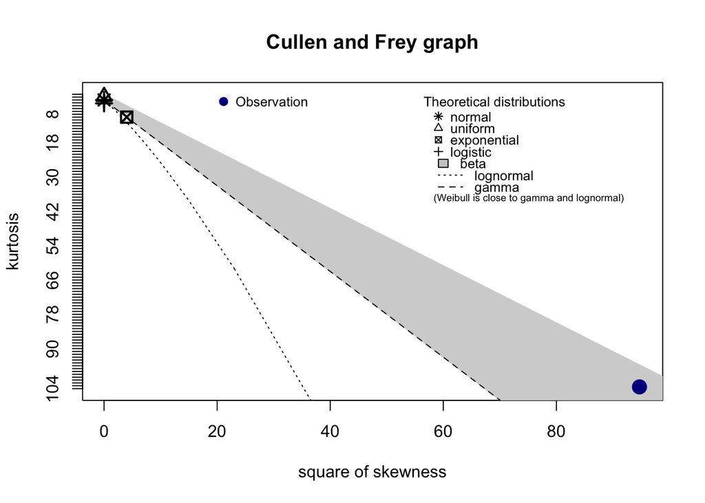

```
## summary statistics
## ------
## min:  0   max:  166342
## median:  84
## mean:  2753.744
## estimated sd:  15835.28
## estimated skewness:  9.731161
## estimated kurtosis:  103.4007
```

```r
descdist(sell_freq$transaction, discrete=FALSE)
```

- Gamma distribution

```r
sell.fit.gamma <- fitdist(sell_freq$transactions, distr = "gamma", method = "mle", lower = c(0, 0), start = list(scale = 1, shape = 1))
#plot(sell.fit.gamma)
```

- Normal distribution

```r
sell.fit.norm <- fitdist(sell_freq$transactions, distr = "norm", method = "mle")
#plot(sell.fit.norm)
```

- Poison distribution

```r
sell.fit.pois <- fitdist(sell_freq$transactions, distr = "pois", method = "mle")
#plot(sell.fit.pois)
```

- Exponential distribution

```r
sell.fit.exp <- fitdist(sell_freq$transactions, distr = "exp", method = "mme")
#plot(sell.fit.exp)
```

- Comparison

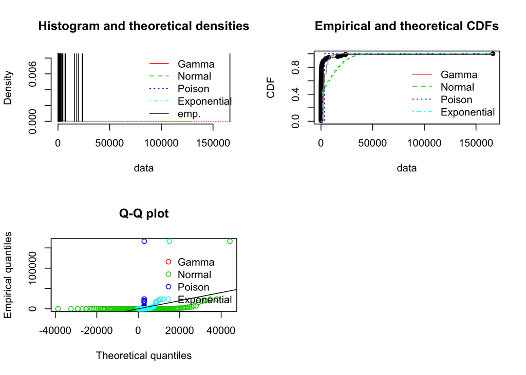

```r
par(mfrow=c(2,2))
plot.legend <- c("Gamma", "Normal", "Poison", "Exponential")
denscomp(list(sell.fit.gamma, sell.fit.norm, sell.fit.pois, sell.fit.exp), legendtext = plot.legend)
cdfcomp (list(sell.fit.gamma, sell.fit.norm, sell.fit.pois, sell.fit.exp), legendtext = plot.legend)
qqcomp  (list(sell.fit.gamma, sell.fit.norm, sell.fit.pois, sell.fit.exp), legendtext = plot.legend)
```

- Trying to fit without the outliers

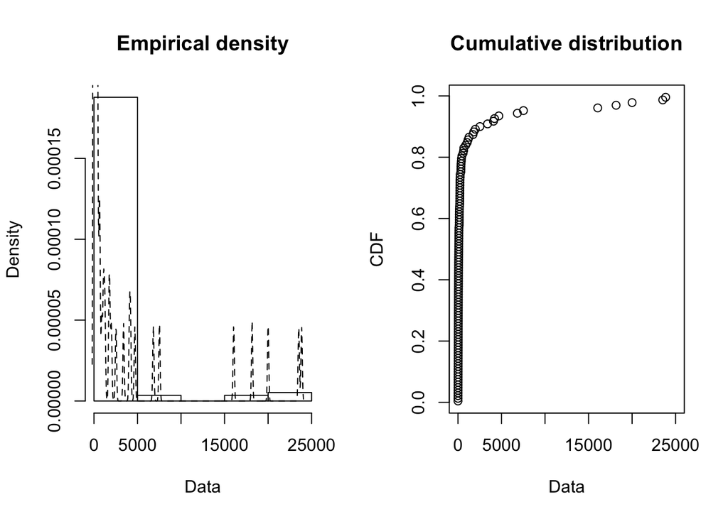

```r
plotdist(new_sell_freq$transaction, histo = TRUE, demp = TRUE)
```

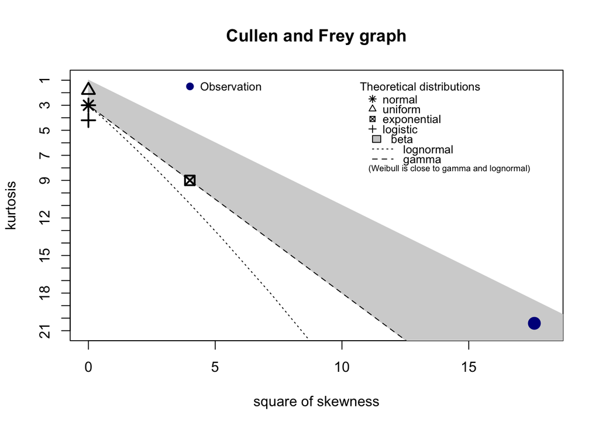

```
## summary statistics
## ------
## min:  1   max:  23854
## median:  84
## mean:  1355.183
## estimated sd:  4285.906
## estimated skewness:  4.193823
## estimated kurtosis:  20.41199
```

```r
descdist(new_sell_freq$transaction, discrete=FALSE)
```

- Gamma distribution

```r
nsell.fit.gamma <- fitdist(new_sell_freq$transactions, distr = "gamma", method = "mle", lower = c(0, 0), start = list(scale = 1, shape = 1))
#plot(nsell.fit.gamma)
```

- Normal distribution

```r
nsell.fit.norm <- fitdist(new_sell_freq$transactions, distr = "norm", method = "mle")
#plot(nsell.fit.norm)
```

- Lognormal distribution

```r
nsell.fit.lnorm <- fitdist(new_sell_freq$transactions, distr = "lnorm", method = "mle")
#plot(nsell.fit.lnorm)
```

- Poison distribution

```r
nsell.fit.pois <- fitdist(new_sell_freq$transactions, distr = "pois", method = "mle")
#plot(nsell.fit.pois)
```

- Exponential distribution

```r
nsell.fit.exp <- fitdist(new_sell_freq$transactions, distr = "exp", method = "mme")
#plot(nsell.fit.exp)
```

- Comparison

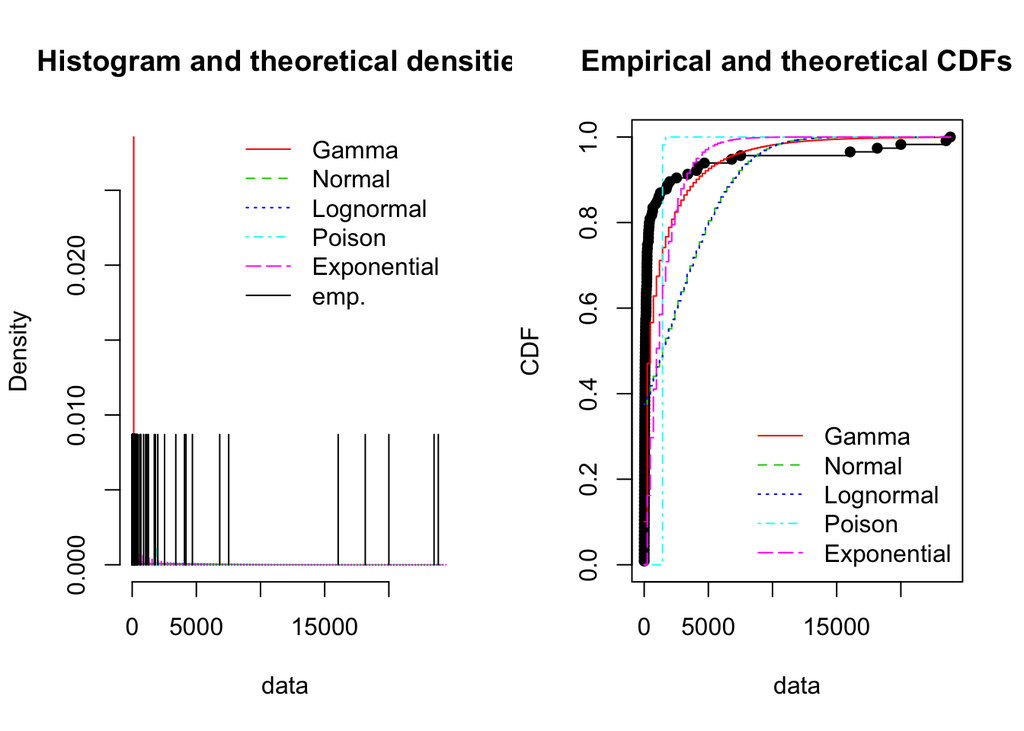

```r
par(mfrow=c(1,2))
plot.legend <- c("Gamma", "Normal", "Lognormal", "Poison", "Exponential")
denscomp(list(nsell.fit.gamma, nsell.fit.norm, nsell.fit.norm,
              nsell.fit.pois, nsell.fit.exp), legendtext = plot.legend)
cdfcomp (list(nsell.fit.gamma, nsell.fit.norm, nsell.fit.norm,
              nsell.fit.pois, nsell.fit.exp), legendtext = plot.legend)
```

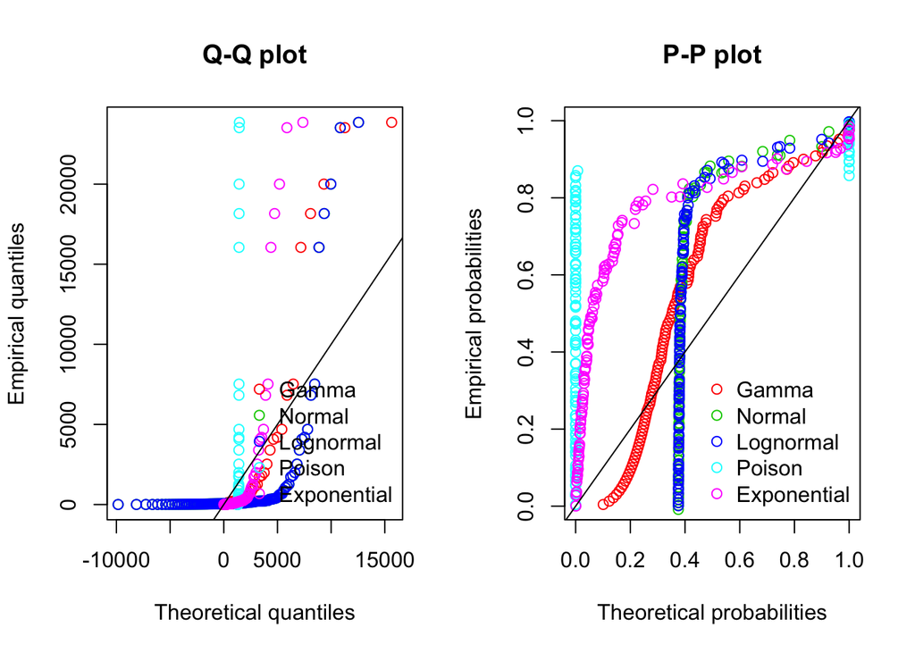

```r
qqcomp  (list(nsell.fit.gamma, nsell.fit.norm, nsell.fit.norm,
              nsell.fit.pois, nsell.fit.exp), legendtext = plot.legend)
ppcomp (list(nsell.fit.gamma, nsell.fit.norm, nsell.fit.norm,
              nsell.fit.pois, nsell.fit.exp), legendtext = plot.legend)
```

##### Buyer

- The plot of buyer’s transcractions frequency

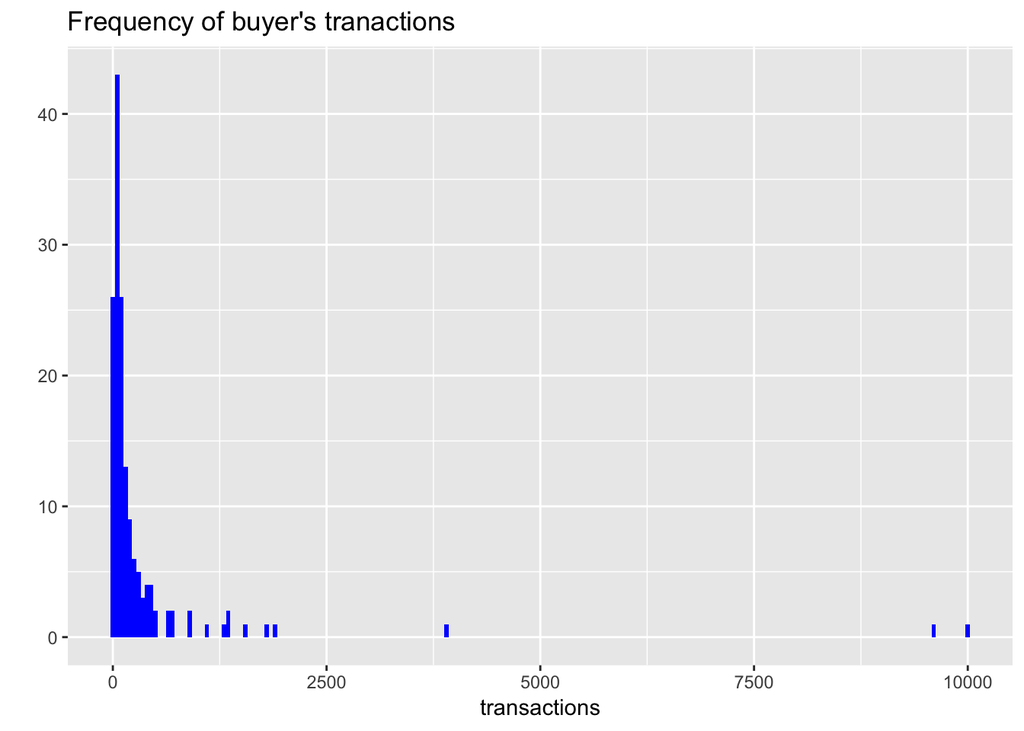

```r
#summary(buy_freq)
qsell <- qplot(buy_freq$transactions, data = buy_freq,
               geom = "histogram",
               binwidth = 50,
               main = "Frequency of buyer's tranactions",
               xlab = "transactions",
               fill=I("blue"))
qsell
```

- Look at the buyer transactions frequency stats

```r
#summary(buy_freq)
#head(buy_freq)
#tail(buy_freq)
```

- If we remove frequency 0, and the 9585, 9992 transactions data

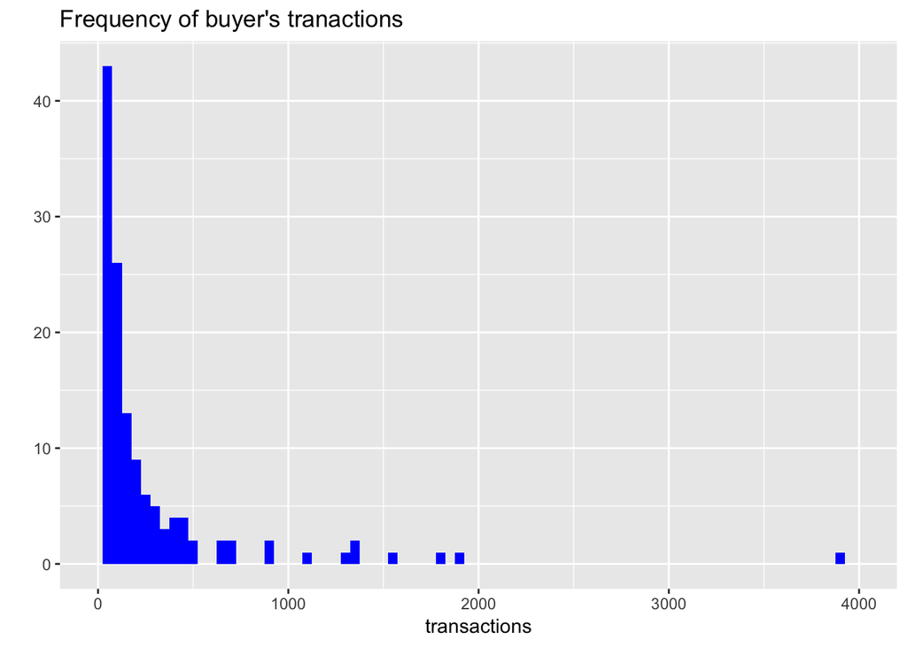

```r
new_buy_freq <- subset(buy_freq, transactions > 0 & transactions < 9585)
#summary(new_buy_freq)
qplot(new_buy_freq$transactions, data = new_buy_freq,
      geom = "histogram",
      binwidth = 50,
      main = "Frequency of buyer's tranactions",
      xlim = c(0, 4000),
      xlab = "transactions",
      fill=I("blue"))
```

#### Trying to fit

- First, use Cullen and Fury graph to see which distribution fit the most
- Lognormal distribution can not fit the data which has zero inside
- Compare the gamma, normal, poison and exponential distribution

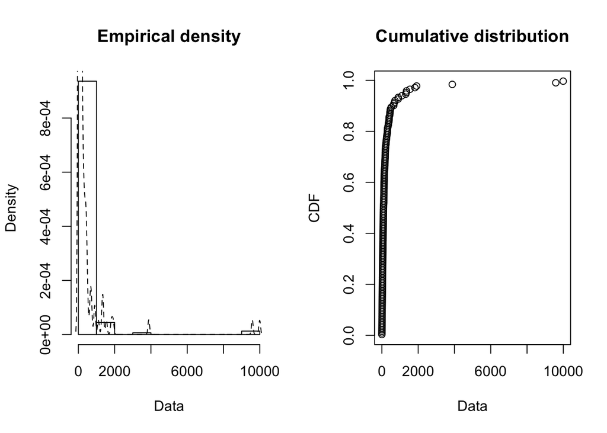

```r
plotdist(buy_freq$transaction, histo = TRUE, demp = TRUE)
```

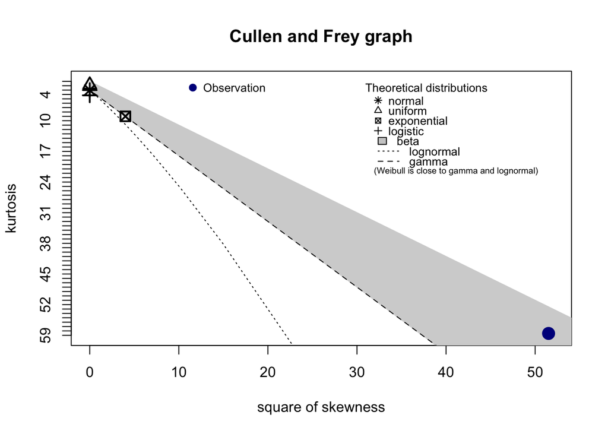

```
## summary statistics
## ------
## min:  0   max:  9992
## median:  88
## mean:  353.0064
## estimated sd:  1162.387
## estimated skewness:  7.17668
## estimated kurtosis:  58.57461
```

```r
descdist(buy_freq$transaction, discrete=FALSE)
```

- Gamma distribution

```r
buy.fit.gamma <- fitdist(buy_freq$transactions, distr = "gamma", method = "mle", lower = c(0, 0), start = list(scale = 1, shape = 1))
#plot(buy.fit.gamma)
```

- Normal distribution

```r
buy.fit.norm <- fitdist(buy_freq$transactions, distr = "norm", method = "mle")
#plot(buy.fit.norm)
```

- Poison distribution

```r
buy.fit.pois <- fitdist(buy_freq$transactions, distr = "pois", method = "mle")
#plot(buy.fit.pois)
```

- Exponential distribution

```r
buy.fit.exp <- fitdist(buy_freq$transactions, distr = "exp", method = "mme")
#plot(buy.fit.exp)
```

- Comparison

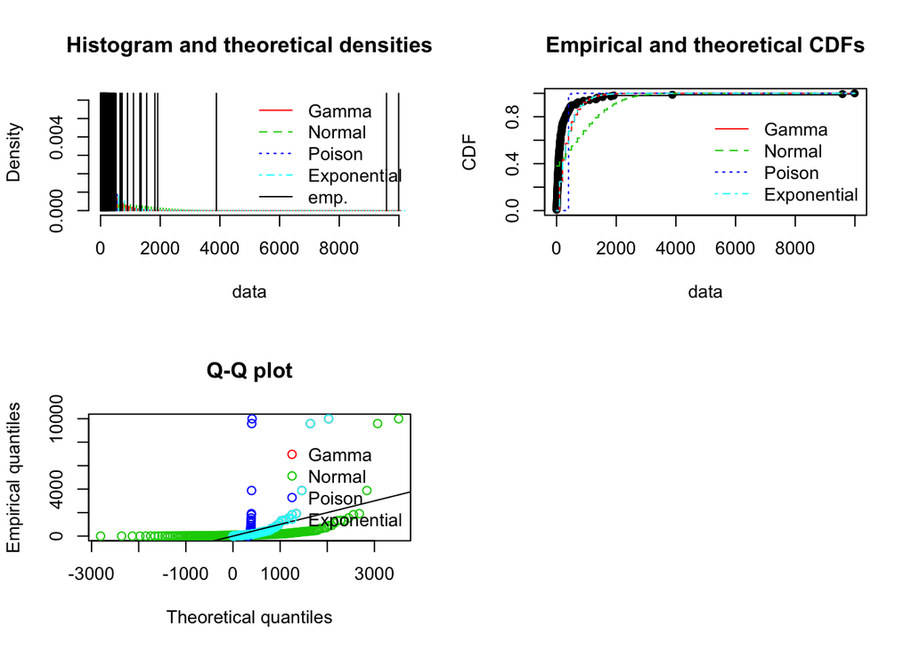

```r
par(mfrow=c(2,2))
plot.legend <- c("Gamma", "Normal", "Poison", "Exponential")
denscomp(list(buy.fit.gamma, buy.fit.norm, buy.fit.pois, buy.fit.exp), legendtext = plot.legend)
cdfcomp (list(buy.fit.gamma, buy.fit.norm, buy.fit.pois, buy.fit.exp), legendtext = plot.legend)
qqcomp  (list(buy.fit.gamma, buy.fit.norm, buy.fit.pois, buy.fit.exp), legendtext = plot.legend)
```

- Trying to fit without the outliers

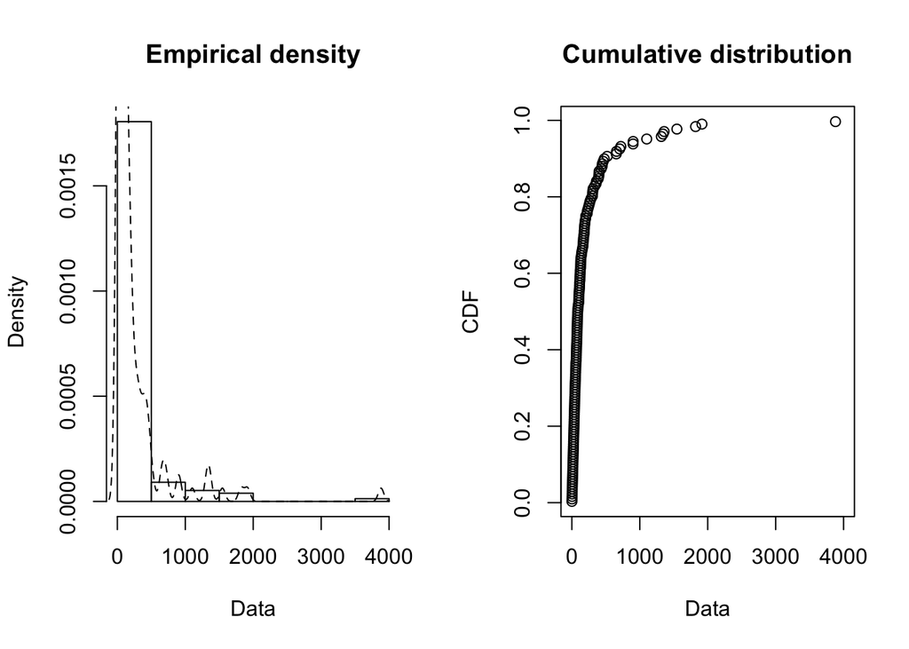

```r
plotdist(new_buy_freq$transaction, histo = TRUE, demp = TRUE)
```

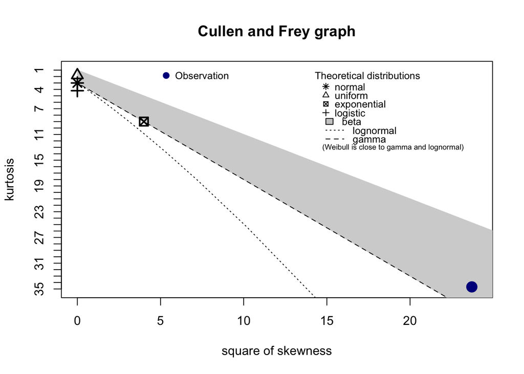

```
## summary statistics
## ------
## min:  1   max:  3881
## median:  86.5
## mean:  232.7597
## estimated sd:  444.9228
## estimated skewness:  4.869715
## estimated kurtosis:  34.68011
```

```r
descdist(new_buy_freq$transaction, discrete=FALSE)
```

- Gamma distribution

```r
nbuy.fit.gamma <- fitdist(new_buy_freq$transactions, distr = "gamma", method = "mle", lower = c(0, 0), start = list(scale = 1, shape = 1))
#plot(nbuy.fit.gamma)
```

- Normal distribution

```r
nbuy.fit.norm <- fitdist(new_buy_freq$transactions, distr = "norm", method = "mle")
#plot(nbuy.fit.norm)
```

- Lognormal distribution

```r
nbuy.fit.lnorm <- fitdist(new_buy_freq$transactions, distr = "lnorm", method = "mle")
#plot(nbuy.fit.lnorm)
```

- Poison distribution

```r
nbuy.fit.pois <- fitdist(new_buy_freq$transactions, distr = "pois", method = "mle")
#plot(nbuy.fit.pois)
```

- Exponential distribution

```r
nbuy.fit.exp <- fitdist(new_buy_freq$transactions, distr = "exp", method = "mme")
#plot(nbuy.fit.exp)
```

- Comparison

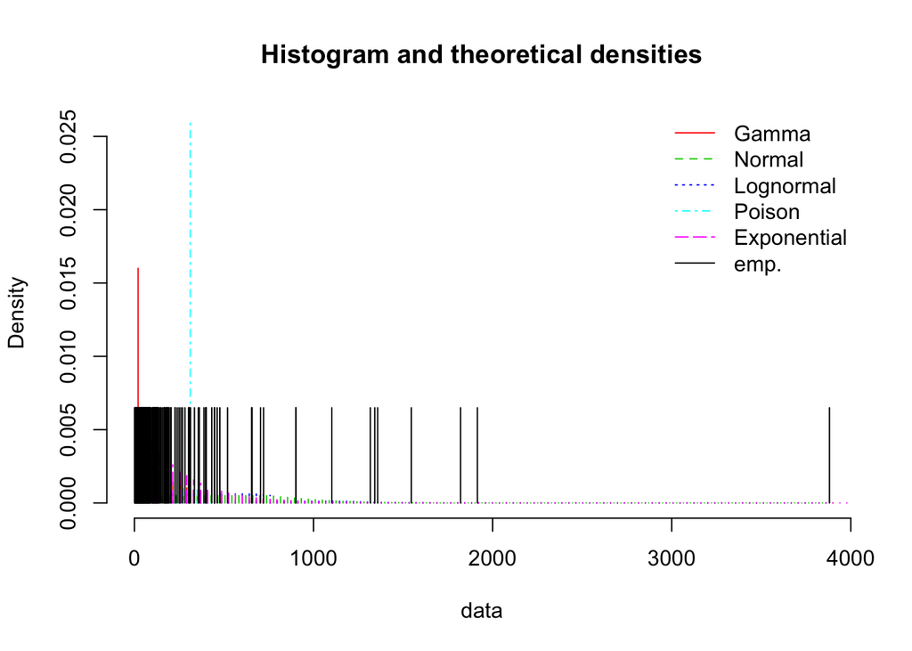

```r
par(mfrow=c(1,1))
plot.legend <- c("Gamma", "Normal", "Lognormal", "Poison", "Exponential")
denscomp(list(nbuy.fit.gamma, nbuy.fit.norm, nbuy.fit.norm,
              nbuy.fit.pois, nbuy.fit.exp), legendtext = plot.legend)
```

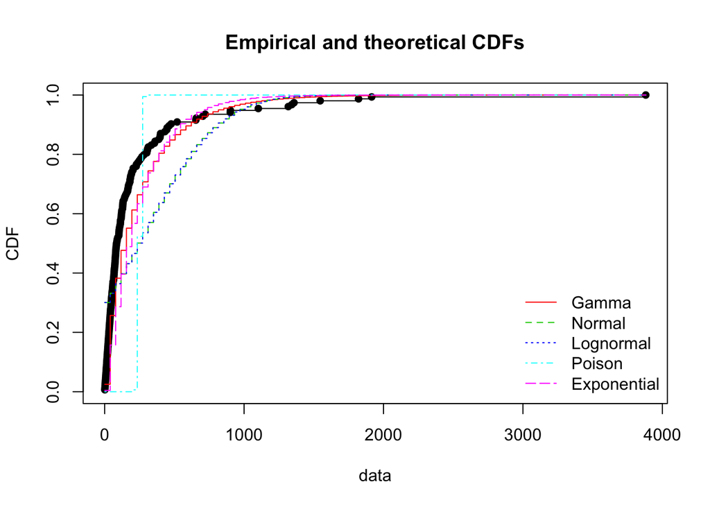

```r
cdfcomp (list(nbuy.fit.gamma, nbuy.fit.norm, nbuy.fit.norm,
              nbuy.fit.pois, nbuy.fit.exp), legendtext = plot.legend)
```

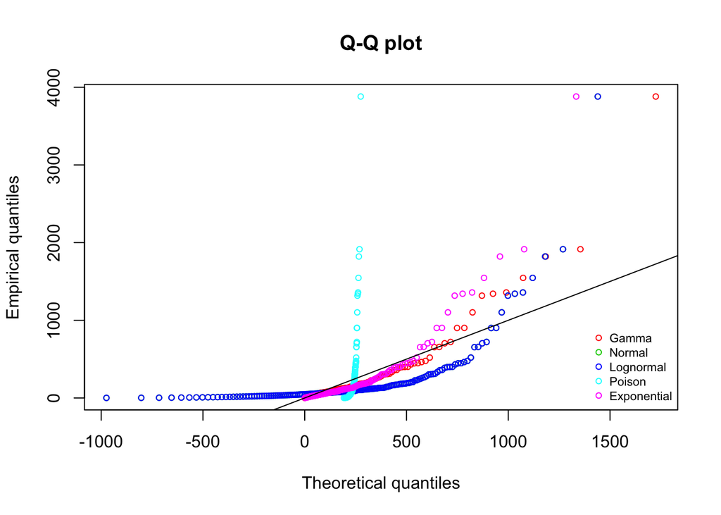

```r
qqcomp  (list(nbuy.fit.gamma, nbuy.fit.norm, nbuy.fit.norm,
              nbuy.fit.pois, nbuy.fit.exp), legendtext = plot.legend, cex=0.7)
```

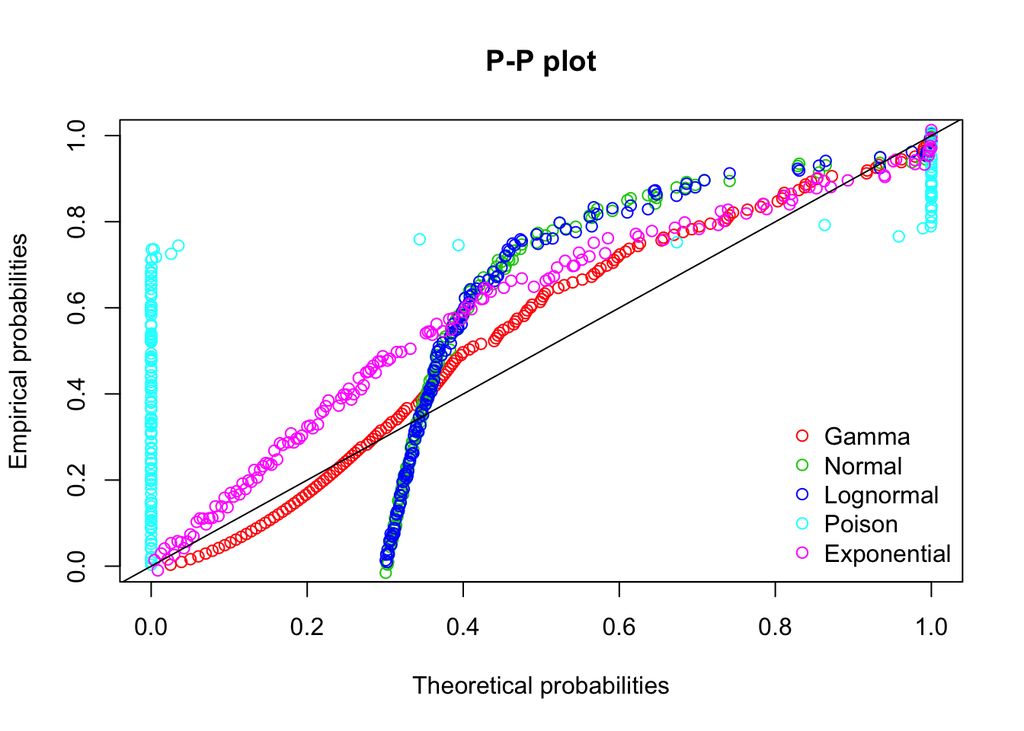

```r
ppcomp (list(nbuy.fit.gamma, nbuy.fit.norm, nbuy.fit.norm,
              nbuy.fit.pois, nbuy.fit.exp), legendtext = plot.legend)
```

### Question 2: How can we create layers of transactions with increasing amounts?

- Finding the best value for the number of layers
- Since there are about 400,000 transactions
- I decide to seperate the data into around 20,000 data in each layer
- There are 20 layers
- Convert Unix Timestamp to Date

```r
normal_data$unixTime <- strftime(anytime::anydate(normal_data$unixTime), format = "%m/%d/%Y")
```

- Select unique buyers as the feature as each layer

```r
layer1 <- subset(normal_data, normal_data$tokenAmount < total_token*2.1325*10^(-9))
layer1_cor <- data.frame(unique(layer1$unixTime))
colnames(layer1_cor) <- c('Date')
layer1_cor <- merge(x = layer1_cor, y = price[, c("Date", "Close")], by = "Date", all.x = TRUE)
colnames(layer1) <- c('Seller', 'Buyer', 'Date', 'tokenAmount')
layer1_cor[,"Unique_Buyer"] <- NA
for(date in layer1_cor$Date)
{
  ubuyer <- subset(layer1, layer1$Date == date)
  ubuyer <- count(unique(ubuyer$Buyer))
  layer1_cor$Unique_Buyer[layer1_cor$Date == date] <- nrow(ubuyer)
}
```

```r
layer2 <- subset(normal_data, total_token*2.1425*10^(-9) > normal_data$tokenAmount &
                  normal_data$tokenAmount > total_token*2.1325*10^(-9))
layer2_cor <- data.frame(unique(layer2$unixTime))
colnames(layer2_cor) <- c('Date')
layer2_cor <- merge(x = layer2_cor, y = price[, c("Date", "Close")], by = "Date", all.x = TRUE)
colnames(layer2) <- c('Seller', 'Buyer', 'Date', 'tokenAmount')
layer2_cor[,"Unique_Buyer"] <- NA
for(date in layer2_cor$Date)
{
  ubuyer <- subset(layer2, layer2$Date == date)
  ubuyer <- count(unique(ubuyer$Buyer))
  layer2_cor$Unique_Buyer[layer2_cor$Date == date] <- nrow(ubuyer)
}
```

```r
layer3 <- subset(normal_data, total_token*2.21*10^(-9) > normal_data$tokenAmount &
                  normal_data$tokenAmount > total_token*2.1425*10^(-9))
layer3_cor <- data.frame(unique(layer3$unixTime))
colnames(layer3_cor) <- c('Date')
layer3_cor <- merge(x = layer3_cor, y = price[, c("Date", "Close")], by = "Date", all.x = TRUE)
colnames(layer3) <- c('Seller', 'Buyer', 'Date', 'tokenAmount')
layer3_cor[,"Unique_Buyer"] <- NA
for(date in layer3_cor$Date)
{
  ubuyer <- subset(layer3, layer3$Date == date)
  ubuyer <- count(unique(ubuyer$Buyer))
  layer3_cor$Unique_Buyer[layer3_cor$Date == date] <- nrow(ubuyer)
}
```

```r
layer4 <- subset(normal_data, total_token*2.82*10^(-9) > normal_data$tokenAmount &
                  normal_data$tokenAmount > total_token*2.21*10^(-9))
layer4_cor <- data.frame(unique(layer4$unixTime))
colnames(layer4_cor) <- c('Date')
layer4_cor <- merge(x = layer4_cor, y = price[, c("Date", "Close")], by = "Date", all.x = TRUE)
colnames(layer4) <- c('Seller', 'Buyer', 'Date', 'tokenAmount')
layer4_cor[,"Unique_Buyer"] <- NA
for(date in layer4_cor$Date)
{
  ubuyer <- subset(layer4, layer4$Date == date)
  ubuyer <- count(unique(ubuyer$Buyer))
  layer4_cor$Unique_Buyer[layer4_cor$Date == date] <- nrow(ubuyer)
}
```

```r
layer5 <- subset(normal_data, total_token*2.8275*10^(-9) > normal_data$tokenAmount &
                  normal_data$tokenAmount > total_token*2.82*10^(-9))
layer5_cor <- data.frame(unique(layer5$unixTime))
colnames(layer5_cor) <- c('Date')
layer5_cor <- merge(x = layer5_cor, y = price[, c("Date", "Close")], by = "Date", all.x = TRUE)
colnames(layer5) <- c('Seller', 'Buyer', 'Date', 'tokenAmount')
layer5_cor[,"Unique_Buyer"] <- NA
for(date in layer5_cor$Date)
{
  ubuyer <- subset(layer5, layer5$Date == date)
  ubuyer <- count(unique(ubuyer$Buyer))
  layer5_cor$Unique_Buyer[layer5_cor$Date == date] <- nrow(ubuyer)
}
```

```r
layer6 <- subset(normal_data, total_token*2.95*10^(-9) > normal_data$tokenAmount &
                  normal_data$tokenAmount > total_token*2.8275*10^(-9))
layer6_cor <- data.frame(unique(layer6$unixTime))
colnames(layer6_cor) <- c('Date')
layer6_cor <- merge(x = layer6_cor, y = price[, c("Date", "Close")], by = "Date", all.x = TRUE)
colnames(layer6) <- c('Seller', 'Buyer', 'Date', 'tokenAmount')
layer6_cor[,"Unique_Buyer"] <- NA
for(date in layer6_cor$Date)
{
  ubuyer <- subset(layer6, layer6$Date == date)
  ubuyer <- count(unique(ubuyer$Buyer))
  layer6_cor$Unique_Buyer[layer6_cor$Date == date] <- nrow(ubuyer)
}
```

```r
layer7 <- subset(normal_data, total_token*3.025*10^(-9) > normal_data$tokenAmount &
                  normal_data$tokenAmount > total_token*2.95*10^(-9))
layer7_cor <- data.frame(unique(layer7$unixTime))
colnames(layer7_cor) <- c('Date')
layer7_cor <- merge(x = layer7_cor, y = price[, c("Date", "Close")], by = "Date", all.x = TRUE)
colnames(layer7) <- c('Seller', 'Buyer', 'Date', 'tokenAmount')
layer7_cor[,"Unique_Buyer"] <- NA
for(date in layer7_cor$Date)
{
  ubuyer <- subset(layer7, layer7$Date == date)
  ubuyer <- count(unique(ubuyer$Buyer))
  layer7_cor$Unique_Buyer[layer7_cor$Date == date] <- nrow(ubuyer)
}
```

```r
layer8 <- subset(normal_data, total_token*3.08*10^(-9) > normal_data$tokenAmount &
                  normal_data$tokenAmount > total_token*3.025*10^(-9))
layer8_cor <- data.frame(unique(layer8$unixTime))
colnames(layer8_cor) <- c('Date')
layer8_cor <- merge(x = layer8_cor, y = price[, c("Date", "Close")], by = "Date", all.x = TRUE)
colnames(layer8) <- c('Seller', 'Buyer', 'Date', 'tokenAmount')
layer8_cor[,"Unique_Buyer"] <- NA
for(date in layer8_cor$Date)
{
  ubuyer <- subset(layer8, layer8$Date == date)
  ubuyer <- count(unique(ubuyer$Buyer))
  layer8_cor$Unique_Buyer[layer8_cor$Date == date] <- nrow(ubuyer)
}
```

```r
layer9 <- subset(normal_data, total_token*3.17*10^(-9) > normal_data$tokenAmount &
                  normal_data$tokenAmount > total_token*3.08*10^(-9))
layer9_cor <- data.frame(unique(layer9$unixTime))
colnames(layer9_cor) <- c('Date')
layer9_cor <- merge(x = layer9_cor, y = price[, c("Date", "Close")], by = "Date", all.x = TRUE)
colnames(layer9) <- c('Seller', 'Buyer', 'Date', 'tokenAmount')
layer9_cor[,"Unique_Buyer"] <- NA
for(date in layer9_cor$Date)
{
  ubuyer <- subset(layer9, layer9$Date == date)
  ubuyer <- count(unique(ubuyer$Buyer))
  layer9_cor$Unique_Buyer[layer9_cor$Date == date] <- nrow(ubuyer)
}
```

```r
layer10 <- subset(normal_data, total_token*4.1*10^(-9) > normal_data$tokenAmount &
                  normal_data$tokenAmount > total_token*3.17*10^(-9))
layer10_cor <- data.frame(unique(layer10$unixTime))
colnames(layer10_cor) <- c('Date')
layer10_cor <- merge(x = layer10_cor, y = price[, c("Date", "Close")], by = "Date", all.x = TRUE)
colnames(layer10) <- c('Seller', 'Buyer', 'Date', 'tokenAmount')
layer10_cor[,"Unique_Buyer"] <- NA
for(date in layer10_cor$Date)
{
  ubuyer <- subset(layer10, layer10$Date == date)
  ubuyer <- count(unique(ubuyer$Buyer))
  layer10_cor$Unique_Buyer[layer10_cor$Date == date] <- nrow(ubuyer)
}
```

```r
layer11 <- subset(normal_data, total_token*5.7*10^(-9) > normal_data$tokenAmount &
                  normal_data$tokenAmount > total_token*4.1*10^(-9))
layer11_cor <- data.frame(unique(layer11$unixTime))
colnames(layer11_cor) <- c('Date')
layer11_cor <- merge(x = layer11_cor, y = price[, c("Date", "Close")], by = "Date", all.x = TRUE)
colnames(layer11) <- c('Seller', 'Buyer', 'Date', 'tokenAmount')
layer11_cor[,"Unique_Buyer"] <- NA
for(date in layer11_cor$Date)
{
  ubuyer <- subset(layer11, layer11$Date == date)
  ubuyer <- count(unique(ubuyer$Buyer))
  layer11_cor$Unique_Buyer[layer11_cor$Date == date] <- nrow(ubuyer)
}
```

```r
layer12 <- subset(normal_data, total_token*8.45*10^(-9) > normal_data$tokenAmount &
                  normal_data$tokenAmount > total_token*5.7*10^(-9))
layer12_cor <- data.frame(unique(layer12$unixTime))
colnames(layer12_cor) <- c('Date')
layer12_cor <- merge(x = layer12_cor, y = price[, c("Date", "Close")], by = "Date", all.x = TRUE)
colnames(layer12) <- c('Seller', 'Buyer', 'Date', 'tokenAmount')
layer12_cor[,"Unique_Buyer"] <- NA
for(date in layer12_cor$Date)
{
  ubuyer <- subset(layer12, layer12$Date == date)
  ubuyer <- count(unique(ubuyer$Buyer))
  layer12_cor$Unique_Buyer[layer12_cor$Date == date] <- nrow(ubuyer)
}
```

```r
layer13 <- subset(normal_data, total_token*9.26*10^(-9) > normal_data$tokenAmount &
                  normal_data$tokenAmount > total_token*8.45*10^(-9))
layer13_cor <- data.frame(unique(layer13$unixTime))
colnames(layer13_cor) <- c('Date')
layer13_cor <- merge(x = layer13_cor, y = price[, c("Date", "Close")], by = "Date", all.x = TRUE)
colnames(layer13) <- c('Seller', 'Buyer', 'Date', 'tokenAmount')
layer13_cor[,"Unique_Buyer"] <- NA
for(date in layer13_cor$Date)
{
  ubuyer <- subset(layer13, layer13$Date == date)
  ubuyer <- count(unique(ubuyer$Buyer))
  layer13_cor$Unique_Buyer[layer13_cor$Date == date] <- nrow(ubuyer)
}
```

```r
layer14 <- subset(normal_data, total_token*2*10^(-8) > normal_data$tokenAmount &
                  normal_data$tokenAmount > total_token*9.26*10^(-9))
layer14_cor <- data.frame(unique(layer14$unixTime))
colnames(layer14_cor) <- c('Date')
layer14_cor <- merge(x = layer14_cor, y = price[, c("Date", "Close")], by = "Date", all.x = TRUE)
colnames(layer14) <- c('Seller', 'Buyer', 'Date', 'tokenAmount')
layer14_cor[,"Unique_Buyer"] <- NA
for(date in layer14_cor$Date)
{
  ubuyer <- subset(layer14, layer14$Date == date)
  ubuyer <- count(unique(ubuyer$Buyer))
  layer14_cor$Unique_Buyer[layer14_cor$Date == date] <- nrow(ubuyer)
}
```

```r
layer15 <- subset(normal_data, total_token*9*10^(-8) > normal_data$tokenAmount &
                  normal_data$tokenAmount > total_token*2*10^(-8))
layer15_cor <- data.frame(unique(layer15$unixTime))
colnames(layer15_cor) <- c('Date')
layer15_cor <- merge(x = layer15_cor, y = price[, c("Date", "Close")], by = "Date", all.x = TRUE)
colnames(layer15) <- c('Seller', 'Buyer', 'Date', 'tokenAmount')
layer15_cor[,"Unique_Buyer"] <- NA
for(date in layer15_cor$Date)
{
  ubuyer <- subset(layer15, layer15$Date == date)
  ubuyer <- count(unique(ubuyer$Buyer))
  layer15_cor$Unique_Buyer[layer15_cor$Date == date] <- nrow(ubuyer)
}
```

```r
layer16 <- subset(normal_data, total_token*4*10^(-7) > normal_data$tokenAmount &
                  normal_data$tokenAmount > total_token*9*10^(-8))
layer16_cor <- data.frame(unique(layer16$unixTime))
colnames(layer16_cor) <- c('Date')
layer16_cor <- merge(x = layer16_cor, y = price[, c("Date", "Close")], by = "Date", all.x = TRUE)
colnames(layer16) <- c('Seller', 'Buyer', 'Date', 'tokenAmount')
layer16_cor[,"Unique_Buyer"] <- NA
for(date in layer16_cor$Date)
{
  ubuyer <- subset(layer16, layer16$Date == date)
  ubuyer <- count(unique(ubuyer$Buyer))
  layer16_cor$Unique_Buyer[layer16_cor$Date == date] <- nrow(ubuyer)
}
```

```r
layer17 <- subset(normal_data, total_token*1.3*10^(-6) > normal_data$tokenAmount &
                  normal_data$tokenAmount > total_token*4*10^(-7))
layer17_cor <- data.frame(unique(layer17$unixTime))
colnames(layer17_cor) <- c('Date')
layer17_cor <- merge(x = layer17_cor, y = price[, c("Date", "Close")], by = "Date", all.x = TRUE)
colnames(layer17) <- c('Seller', 'Buyer', 'Date', 'tokenAmount')
layer17_cor[,"Unique_Buyer"] <- NA
for(date in layer17_cor$Date)
{
  ubuyer <- subset(layer17, layer17$Date == date)
  ubuyer <- count(unique(ubuyer$Buyer))
  layer17_cor$Unique_Buyer[layer17_cor$Date == date] <- nrow(ubuyer)
}
```

```r
layer18 <- subset(normal_data, total_token*4*10^(-6) > normal_data$tokenAmount &
                  normal_data$tokenAmount > total_token*1.3*10^(-6))
layer18_cor <- data.frame(unique(layer18$unixTime))
colnames(layer18_cor) <- c('Date')
layer18_cor <- merge(x = layer18_cor, y = price[, c("Date", "Close")], by = "Date", all.x = TRUE)
colnames(layer18) <- c('Seller', 'Buyer', 'Date', 'tokenAmount')
layer18_cor[,"Unique_Buyer"] <- NA
for(date in layer18_cor$Date)
{
  ubuyer <- subset(layer18, layer18$Date == date)
  ubuyer <- count(unique(ubuyer$Buyer))
  layer18_cor$Unique_Buyer[layer18_cor$Date == date] <- nrow(ubuyer)
}
```

```r
layer19 <- subset(normal_data, total_token*1.5*10^(-5) > normal_data$tokenAmount &
                  normal_data$tokenAmount > total_token*4*10^(-6))
layer19_cor <- data.frame(unique(layer19$unixTime))
colnames(layer19_cor) <- c('Date')
layer19_cor <- merge(x = layer19_cor, y = price[, c("Date", "Close")], by = "Date", all.x = TRUE)
colnames(layer19) <- c('Seller', 'Buyer', 'Date', 'tokenAmount')
layer19_cor[,"Unique_Buyer"] <- NA
for(date in layer19_cor$Date)
{
  ubuyer <- subset(layer19, layer19$Date == date)
  ubuyer <- count(unique(ubuyer$Buyer))
  layer19_cor$Unique_Buyer[layer19_cor$Date == date] <- nrow(ubuyer)
}
```

```r
layer20 <- subset(normal_data, total_token*1 > normal_data$tokenAmount &
                  normal_data$tokenAmount > total_token*1.5*10^(-5))
layer20_cor <- data.frame(unique(layer20$unixTime))
colnames(layer20_cor) <- c('Date')
layer20_cor <- merge(x = layer20_cor, y = price[, c("Date", "Close")], by = "Date", all.x = TRUE)
colnames(layer20) <- c('Seller', 'Buyer', 'Date', 'tokenAmount')
layer20_cor[,"Unique_Buyer"] <- NA
for(date in layer20_cor$Date)
{
  ubuyer <- subset(layer20, layer20$Date == date)
  ubuyer <- count(unique(ubuyer$Buyer))
  layer20_cor$Unique_Buyer[layer20_cor$Date == date] <- nrow(ubuyer)
}
```

- Test correlation between unique buyers and token price in each layer
- I use close price as the token price
- The method is **pearson**
- Since some date in TokenPrice is not exist, use cor function will cause NA
- Layer 1
- Transactions that involve 2.1325 x 10^(-9) × MAXt in amount
- There are 20,391 transactions in layer 1

```r
cor1 <- cor.test(layer1_cor$Close, layer1_cor$Unique_Buyer, method = c("pearson"))$estimate
cor1
```

```
##       cor
## 0.1277518
```

- Layer 2
- Transactions that involve 2.1325x10^(-9) x MAXt ~ 2.1425x10^(-9) × MAXt in amount
- There are 20,391 transactions in layer 2

```r
cor2 <- cor.test(layer2_cor$Close, layer2_cor$Unique_Buyer, method = c("pearson"))$estimate
cor2
```

```
##       cor
## 0.5486809
```

- Layer 3
- Transactions that involve 2.1425x10^(-9) x MAXt ~ 2.21x10^(-9) × MAXt in amount
- There are 20,740 transactions in layer 3

```r
cor3 <- cor.test(layer3_cor$Close, layer3_cor$Unique_Buyer, method = c("pearson"))$estimate
cor3
```

```
##       cor
## 0.2189938
```

```r
cor4 <- cor.test(layer4_cor$Close, layer4_cor$Unique_Buyer, method = c("pearson"))$estimate
cor4
```

```
##       cor
## 0.1325171
```

- Layer 5
- Transactions that involve 2.8275x10^(-9) x MAXt ~ 2.82x10^(-9) × MAXt in amount
- There are 24,839 transactions in layer 5

```r
cor5 <- cor.test(layer5_cor$Close, layer5_cor$Unique_Buyer, method = c("pearson"))$estimate
cor5
```

```
##        cor
## 0.01097274
```

- Layer 6
- Transactions that involve 2.95x10^(-9) x MAXt ~ 2.8275x10^(-9) × MAXt in amount
- There are 21,171 transactions in layer 6

```r
cor6 <- cor.test(layer6_cor$Close, layer6_cor$Unique_Buyer, method = c("pearson"))$estimate
cor6
```

```
##          cor
## -0.003367146
```

- Layer 7
- Transactions that involve 3.025x10^(-9) x MAXt ~ 2.95x10^(-9) × MAXt in amount
- There are 19,641 transactions in layer 7

```r
cor7 <- cor.test(layer7_cor$Close, layer7_cor$Unique_Buyer, method = c("pearson"))$estimate
cor7
```

```
##        cor
## -0.1567672
```

- Layer 8
- Transactions that involve 3.08x10^(-9) x MAXt ~ 3.025x10^(-9) × MAXt in amount
- There are 20,573 transactions in layer 8

```r
cor8 <- cor.test(layer8_cor$Close, layer8_cor$Unique_Buyer, method = c("pearson"))$estimate
cor8
```

```
##        cor
## 0.07111708
```

- Layer 9
- Transactions that involve 3.17x10^(-9) x MAXt ~ 3.08x10^(-9) × MAXt in amount
- There are 20,784 transactions in layer 9

```r
cor9 <- cor.test(layer9_cor$Close, layer9_cor$Unique_Buyer, method = c("pearson"))$estimate
cor9
```

```
##       cor
## -0.106783
```

- Layer 10
- Transactions that involve 4.1*10^(-9) x MAXt ~ 3.17x10^(-9) × MAXt in amount
- There are 21,633 transactions in layer 10

```r
cor10 <- cor.test(layer10_cor$Close, layer10_cor$Unique_Buyer, method = c("pearson"))$estimate
cor10
```

```
##        cor
## 0.04769765
```

- Layer 11
- Transactions that involve 5.7x10^(-9) x MAXt ~ 4.1*10^(-9) × MAXt in amount
- There are 20,367 transactions in layer 11

```r
cor11 <- cor.test(layer11_cor$Close, layer11_cor$Unique_Buyer, method = c("pearson"))$estimate
cor11
```

```
##          cor
## -0.009211606
```

- Layer 12
- Transactions that involve 8.45x10^(-9)x MAXt ~ 5.7x10^(-9) × MAXt in amount
- There are 20,792 transactions in layer 12

```r
cor12 <- cor.test(layer12_cor$Close, layer12_cor$Unique_Buyer, method = c("pearson"))$estimate
cor12
```

```
##        cor
## 0.01819158
```

- Layer 13
- Transactions that involve 9.26x10^(-9) x MAXt ~ 8.45x10^(-9) × MAXt in amount
- There are 23,697 transactions in layer 13

```r
cor13 <- cor.test(layer13_cor$Close, layer13_cor$Unique_Buyer, method = c("pearson"))$estimate
cor13
```

```
##        cor
## -0.1767222
```

- Layer 14
- Transactions that involve 2*10^(-8) x MAXt ~ 9.26x10^(-9) × MAXt in amount
- There are 19,166 transactions in layer 14

```r
cor14 <- cor.test(layer14_cor$Close, layer14_cor$Unique_Buyer, method = c("pearson"))
cor14
```

```
##
##  Pearson's product-moment correlation
##
## data:  layer14_cor$Close and layer14_cor$Unique_Buyer
## t = -0.84234, df = 303, p-value = 0.4003
## alternative hypothesis: true correlation is not equal to 0
## 95 percent confidence interval:
##  -0.1597749  0.0643219
## sample estimates:
##         cor
## -0.04833473
```

- Layer 15
- Transactions that involve 9x10^(-8) x MAXt ~ 2x10^(-8) × MAXt in amount
- There are 19,495 transactions in layer 15

```r
cor15 <- cor.test(layer15_cor$Close, layer15_cor$Unique_Buyer, method = c("pearson"))$estimate
cor15
```

```
##        cor
## 0.02397768
```

- Layer 16
- Transactions that involve 4x10^(-7) x MAXt ~ 9x10^(-8) × MAXt in amount
- There are 19,027 transactions in layer 16

```r
cor16 <- cor.test(layer16_cor$Close, layer16_cor$Unique_Buyer, method = c("pearson"))$estimate
cor16
```

```
##       cor
## 0.3248082
```

- Layer 17
- Transactions that involve 1.3x10^(-6) x MAXt ~ 4x10^(-7) × MAXt in amount
- There are 20,781 transactions in layer 17

```r
cor17 <- cor.test(layer17_cor$Close, layer17_cor$Unique_Buyer, method = c("pearson"))$estimate
cor17
```

```
##       cor
## 0.4626471
```

- Layer 18
- Transactions that involve 4x10^(-6) x MAXt ~ 1.3x10^(-6) × MAXt in amount
- There are 22,865 transactions in layer 18

```r
cor18 <- cor.test(layer18_cor$Close, layer18_cor$Unique_Buyer, method = c("pearson"))$estimate
cor18
```

```
##       cor
## 0.4178417
```

- Layer 19
- Transactions that involve 1.5*10^(-5) x MAXt ~ 4x10^(-6) × MAXt in amount
- There are 21,975 transactions in layer 19

```r
cor19 <- cor.test(layer19_cor$Close, layer19_cor$Unique_Buyer, method = c("pearson"))$estimate
cor19
```

```
##       cor
## 0.3676598
```

- Layer 20
- Transactions that involve more than 1.5*10^(-5) x MAXt in amount
- There are 14,814 transactions in layer 20

```r
cor20 <- cor.test(layer20_cor$Close, layer20_cor$Unique_Buyer, method = c("pearson"))$estimate
cor20
```

```
##       cor
## 0.3662488
```

```r
cor20[['cor']]
```

```
## [1] 0.3662488
```

```r
cor_result <- c(cor1[['cor']], cor2[['cor']], cor3[['cor']], cor3[['cor']], cor4[['cor']], cor5[['cor']], cor6[['cor']], cor7[['cor']], cor8[['cor']], cor9[['cor']], cor10[['cor']], cor11[['cor']], cor12[['cor']], cor13[['cor']], cor14[['cor']], cor15[['cor']], cor16[['cor']], cor17[['cor']], cor18[['cor']], cor19['cor'], cor20[['cor']])
summary(cor_result)
```

```
##      Min.   1st Qu.    Median      Mean   3rd Qu.      Max.
## -0.176722  0.007388  0.099434  0.145262  0.335168  0.548681
```

# Project 2

## Question 1:

```r
layer2_date <- data.frame(unique(layer2$Date))
colnames(layer2_date) <- c('Date')
layer2_reg <- merge(x = layer2_date, y = price[, c("Date", "Close")], by = "Date", all.x = TRUE)

layer6_date <- data.frame(unique(layer6$Date))
colnames(layer6_date) <- c('Date')
layer6_reg <- merge(x = layer6_date, y = price[, c("Date", "Close")], by = "Date", all.x = TRUE)
```

### Feature 1: Unique buyers

#### Layer2

```r
layer2_reg[,"Unique_Buyer"] <- NA
for(date in layer2_reg$Date)
{
  ubuyer <- subset(layer2, layer2$Date == date)
  ubuyer <- count(unique(ubuyer$Buyer))
  layer2_reg$Unique_Buyer[layer2_reg$Date == date] <- nrow(ubuyer)
}
```

#### Layer6

```r
layer6_reg[,"Unique_Buyer"] <- NA
for(date in layer6_reg$Date)
{
  ubuyer <- subset(layer6, layer6$Date == date)
  ubuyer <- count(unique(ubuyer$Buyer))
  layer6_reg$Unique_Buyer[layer6_reg$Date == date] <- nrow(ubuyer)
}
```

### Feature 2: Terms of numbers (x1=number of transactions)

#### Layer2

```r
layer2_reg[,"transactions"] <- NA
for(date in layer2_reg$Date)
{
  trans <- subset(layer2, layer2$Date == date)
  layer2_reg$transactions[layer2_reg$Date == date] <- nrow(trans)
}
```

#### Layer6

```r
layer6_reg[,"transactions"] <- NA
for(date in layer6_reg$Date)
{
  trans <- subset(layer6, layer6$Date == date)
  layer6_reg$transactions[layer6_reg$Date == date] <- nrow(trans)
}
```

#### Layer2

```r
layer2_reg[,"sqr_transactions"] <- NA
for(date in layer2_reg$Date)
{
  trans <- subset(layer2, layer2$Date == date)
  trans <- nrow(trans)
  layer2_reg$sqr_transactions[layer2_reg$Date == date] <- trans*trans
}
```

#### Layer6

```r
layer6_reg[,"sqr_transactions"] <- NA
for(date in layer6_reg$Date)
{
  trans <- subset(layer6, layer6$Date == date)
  trans <- nrow(trans)
  layer6_reg$sqr_transactions[layer6_reg$Date == date] <- trans*trans
}
```

### Feature 4: percentages (x1=percentage of investors who bought more than 10 tokens)

#### Layer2

```r
layer2_reg[,"percentage"] <- NA
for(date in layer2_reg$Date)
{
  trans <- subset(layer2, layer2$Date == date)
  gre10 <- count(trans$Buyer)
  gre10 <- subset(gre10, gre10$freq > 10)
  perc <- nrow(gre10) / nrow(trans)
  layer2_reg$percentage[layer2_reg$Date == date] <- perc
}
```

#### Layer6

```r
layer6_reg[,"percentage"] <- NA
for(date in layer6_reg$Date)
{
  trans <- subset(layer6, layer6$Date == date)
  gre10 <- count(trans$Buyer)
  gre10 <- subset(gre10, gre10$freq > 10)
  perc <- nrow(gre10) / nrow(trans)
  layer6_reg$percentage[layer6_reg$Date == date] <- perc
}
```

## Building multiple regression model

#### Layer2

I found if the features includes square of transactions, the Std. Error is much larger than not included it.

```r
model.layer2 <- lm(Close ~ (Unique_Buyer + transactions + percentage), data = layer2_reg)
model.layer2$coefficients
```

```
##   (Intercept)  Unique_Buyer  transactions    percentage
##  0.9742289684 -0.0009171966  0.0009681677  1.5679670716
```

#### Summary

```r
summary(model.layer2)$coefficients
```

```
##                   Estimate   Std. Error    t value     Pr(>|t|)
## (Intercept)   0.9742289684 0.0461313671 21.1185800 6.841582e-18
## Unique_Buyer -0.0009171966 0.0003763332 -2.4371925 2.195129e-02
## transactions  0.0009681677 0.0003666449  2.6406141 1.381213e-02
## percentage    1.5679670716 1.9159914675  0.8183581 4.205902e-01
```

```r
#model.layer2$fitted.values
```

The Std. Error of percentage is higher that the other two features Trying to take out the percentage features

```r
model.layer2 <- lm(Close ~ (Unique_Buyer + transactions), data = layer2_reg)
model.layer2$coefficients
```

```
##   (Intercept)  Unique_Buyer  transactions
##  0.9877899792 -0.0009433039  0.0009918052
```

#### Summary

```r
summary(model.layer2)$coefficients
```

```
##                   Estimate   Std. Error   t value     Pr(>|t|)
## (Intercept)   0.9877899792 0.0427882128 23.085563 2.604238e-19
## Unique_Buyer -0.0009433039 0.0003726780 -2.531150 1.750247e-02
## transactions  0.0009918052 0.0003632629  2.730268 1.100636e-02
```

```r
#model.layer2$fitted.values
```

Much better

#### Layer6

```r
model.layer6 <- lm(Close ~ (Unique_Buyer + transactions + percentage), data = layer6_reg)
model.layer6$coefficients
```

```
##   (Intercept)  Unique_Buyer  transactions    percentage
##  1.4763693015 -0.0001547325  0.0001481118 -2.9583660587
```

#### Summary

```r
summary(model.layer6)$coefficients
```

```
##                   Estimate   Std. Error    t value     Pr(>|t|)
## (Intercept)   1.4763693015 0.1173056479 12.5856626 1.447319e-12
## Unique_Buyer -0.0001547325 0.0005524454 -0.2800865 7.816275e-01
## transactions  0.0001481118 0.0005388384  0.2748723 7.855868e-01
## percentage   -2.9583660587 6.8482880104 -0.4319862 6.693129e-01
```

```r
#model.layer6$fitted.values
```

Similar situation to layer2

```r
model.layer6 <- lm(Close ~ (Unique_Buyer + transactions), data = layer6_reg)
model.layer6$coefficients
```

```
##   (Intercept)  Unique_Buyer  transactions
##  1.4596108910 -0.0001575403  0.0001534547
```

#### Summary

```r
summary(model.layer6)$coefficients
```

```
##                   Estimate   Std. Error    t value     Pr(>|t|)
## (Intercept)   1.4596108910 0.1090249720 13.3878584 1.949863e-13
## Unique_Buyer -0.0001575403 0.0005440228 -0.2895840 7.743467e-01
## transactions  0.0001534547 0.0005305202  0.2892533 7.745970e-01
```

```r
#model.layer6$fitted.values
```

## Conclusion

No matter the data has higher correlation to unique buyer or not, the multiple regression has the lower Std. Error if the features contain Unique_Buyer and transactions